# Instalación del software de minería de datos en Python

## 1. Jupyter Notebooks

[figure not shown]

Los notebooks son documentos que contienen código, por ejemplo `Python`, y texto enriquecido (parágrafos, ecuaciones, figuras, etcétera). De esta forma podemos ejecutar y ver nuestros análisis a la vez que los vamos documentando. Los notebooks, como este que estáis leyendo, se visualizan vía web y es necesario instalar la `Jupyter Notebook App` para hacerlos funcionar.

### 1.1 Ejemplo

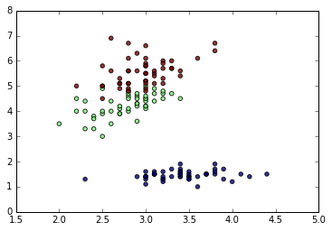

```python
%matplotlib inline

from sklearn.datasets import load_iris
from matplotlib import pyplot as plt

iris = load_iris()
plt.scatter(iris.data[:,1] ,iris.data[:,2], c=iris.target, alpha=0.8)
```

## 2. Distribución Anaconda

La manera más sencilla de instalar todo lo que necesitaremos es usar la distribución [Anaconda](https://www.anaconda.com/distribution/).

Como podéis ver en el siguiente esquema, `Anaconda` es una distribución de código abierto que agrupa los paquetes más importantes para hacer minería de datos en `Python`. Incluye el gestor de paquetes `conda` y un conjunto de librerías de data science, junto con los `Python Notebooks`.

En las próximas actividades, usaremos principalmente las librerías [pandas](https://pandas.pydata.org/) y [numpy](http://www.numpy.org/) para hacer minería de datos, y [matplotlib](https://matplotlib.org/) para la visualisación.

[figure not shown]

### 2.1 Instalación de la distribución

Escoged vuestro sistema operativo y seguid las instrucciones para instalar la distribuión `Anaconda`.

#### 2.1.1 Instalación en Linux

1. Ir a https://www.anaconda.com/download/#linux y bajaros la versión 3.6 de la distribución `Anaconda`.
2. Abrir el terminal y ejecutar el comando `bash ~/Downloads/Anaconda3-5.0.1-Linux-x86_64.sh`. Si el fichero se llama de otra forma, adaptar el comando a vuestra situación.
3. El instalador os pedirá permiso para mostrar la licencia: *"In order to continue the installation process, please review the license agreement. Click Enter to view license terms"*. Aceptr con la tecla `Enter`
4. Leer la licencia, o hacer scroll hasta el final, y escribir `Yes` para aceptarla.
5. El instalador os pedirá el directorio donde lo queréis instalar. Si aceptáis, el directorio por defecto será `/home/<user>/anaconda3`
6. Ahora os pedirá si queréis añadir el path de Anaconda en el `.bashrc`. Decirle que sí.
7. Ejecutar el comando `source ~/.bashrc` para finalizar la instalación.
8. También en el terminal, ejecutar el comando `anaconda-navigator`. Se os obrirá un navegador con la aplicación Anaconda.

#### 2.1.2 Instalación en Windows

1. Ir a https://www.anaconda.com/download/#windows y bajaros la versión 3.6 de la distribución `Anaconda`.
2. Hacer doble-clic en el instalador.
3. Clicar `Siguiente`.
4. Aceptar la licencia.
5. Seleccionar `Solo yo` y clicar `Siguiente`.
6. Seleccionar la carpeta de instalación y clicar `Siguiente`.
7. A continuación os saldrá un diálogo con la opción de añadir Anaconda como variable de entorno en el `PATH`. No seleccionar esta opción. Seleccionar la opción de usar Anaconda como la versión por defecto de Python 3.6. Clicar `Siguiente`.
8. Clicar el botón `Instalar` y esperar hasta que se acabe la instalación.
9. Podéis abrir la aplicación desde el menú de inicio de Windows.

#### 2.1.3 Instalación en macOS

1. Ir a https://www.anaconda.com/download/#macos y bajaros la versión 3.6 de la distribución `Anaconda`.
2. Hcer doble-clic en el instalador.
3. Pasar las pantallas de la Introducción, el Readme y la Licencia.
4. Seleccionar `Instalar solo para mi` y clicar `Continuar`.
5. Clicar el botón `Instalar` y esperar hasta que se acabe la instalación.
6. Podéis abrir la aplicación desde el `Launchpad`.

### 2.2 Anaconda Navigator

El `Anaconda Navigator` es una interfície gráfica de usuario (GUI) que permite ejecutar las aplicaciones incluidas en la distribución e instalar paquetes sin tener que usar la línia de comandos.

[figure not shown]

### 2.3 Nuestro primer notebook

Nosotros usaremos básicamente los `Jupyter Notebooks`, como hemos comentado antes. Si abrimos la aplicación de los `Jupyter Notebooks` nos aparecerá el `Jupyter dashboard`. Para crear un nuevo notebook, clicamos el botón `New` y seleccionamos `Python 3`.

[figure not shown]

Una vez creado, ya podemos empezar a editar nuestro primer notebook. En el menú de ayuda, podéis consultar el `User Interface Tour` para familiarizaros con el entorno.

[figure not shown]